# Cash Flow Forecasting Using Deep Learning

# Define the Model

```python
from keras.models     import Model
from keras.layers     import Input, Conv1D, Dense, Dropout, Lambda, concatenate
from keras.optimizers import Adam, TFOptimizer
from keras.layers     import TimeDistributed

def create_model_cash(days_forecast, multby11 = True, n_channels = 1,
                      qty_dilations = 13, dropout_between_1Dconvs = False,
                      predictor_qty = 20, n_filters = 32):

  # convolutional layer parameters
  filter_width   = 2 #this is effectively the dilation power, only very long sequences would need >2
  dilation_rates = [1, 2, 4, 8, 16, 32, 64, 128, 256, 512, 1024, 2048, 4000][0:qty_dilations]

  if(multby11):
    seq_length = days_forecast*11
  else:
    seq_length = days_forecast

  # define an input history series and pass it through a stack of dilated causal convolutions.
  # defined using the functional API (as opposed to sequential, eg model.add())
  input_sequence = Input(shape=(None, predictor_qty))
  x = input_sequence

  # 8x 1D dilated causal convolutions
  # input shape  (batch, steps, channels)
  # output shape (batch, new_steps, filters)
  for dilation_rate in dilation_rates:
    x = Conv1D(filters       = n_filters,
             kernel_size   = filter_width,
             padding       = 'causal',
             dilation_rate = dilation_rate)(x)
    if(dropout_between_1Dconvs):
      x = Dropout(0.2)(x)
  #NB no activation after Conv1D

  # dense layer, ReLU activation
  # We don't have to use TimeDistributed, doesn't make difference.
  # So alternative would be: x = Dense(128, activation='relu')(x)
  x = TimeDistributed(Dense(128, activation='relu'))(x)

  # dropout, 20%
  x = Dropout(0.2)(x)

  # softmax, NB only 1D output.
  # No activation, a linear output unconstrained to any range
  # We don't have to use TimeDistributed, doesn't make difference.
  # So alternative would be: x = Dense(n_channels)(x)
  x = TimeDistributed(Dense(n_channels))(x)

  # extract the last few time step(s) as the training
  # x will be shape [n_examples, n_timesteps, 1]
  def slice(x, seq_length):
    return x[:,-(seq_length):,:]
    #returns as many rows as there were examples in the batch

  output_sequence = Lambda(slice, arguments={'seq_length':seq_length})(x)

  model = Model(inputs  = input_sequence,
                outputs = output_sequence)

  return(model)
```

```python
#let's build a model for fortnite forecasts first
model_cash14 = create_model_cash(days_forecast=14)
model_cash14.summary()
```

```python
from keras import callbacks

######################################################################
## Compile Model with Side by Side Validation
model_cash14.compile(optimizer = Adam(),
                     loss      = 'mean_absolute_error')
# hook up to Tensorboard for keeping records of progress
# to use the Tensorboard, go to command line, set cd "current project directory", then:
# tensorboard --logdir GraphRMS
# then
# http://localhost:6006/

## Tensorboard callback
tbCallback_cash  = callbacks.TensorBoard(log_dir        = './Tensorboard_cash14',
                                         histogram_freq = 0,
                                         write_graph    = True)
## Checkpoint callback
cpCallback_cash  = callbacks.ModelCheckpoint('./Checkpoints/cash_{epoch:02d}.hdf5',
                                             monitor    = 'val_acc',
                                             verbose    = 1,
                                             save_best_only=True,
                                             mode       = 'max')

##Earlystopping, stop training when validation accuracy ceases to improve
esCallback_cash  = callbacks.EarlyStopping(monitor   = 'val_loss',
                                           min_delta = 0.00005,
                                           patience  = 200,
                                           verbose   = 0,
                                           mode      = 'auto',
                                           baseline  = None)
```

Now we’re ready to create train, validation and test instances of the the generator. We can then fit the model. These two tasks are in one code chunk because we must re-instantiate the generator each time we fit the model.

```r
## Let's fit using walk forward validation
## NOTE use of model.fit_generator(), not model.fit()
epochs     = 50
batch_size = 64

train_gen = yield_xy(x_train_py, y_train_py[:,:,0], records_per_example, batch_size)
test_gen  = yield_xy(x_test_py,  y_test_py[:,:,0],  records_per_example, batch_size)

history_cash = model_cash14.fit_generator(
                              generator        = train_gen,
                              steps_per_epoch  = int((x_train_py.shape[1] - records_per_example)
                                                      / batch_size/11),
                              epochs           = epochs,
                              validation_data  = valid_gen,
                              validation_steps = int((x_valid_py.shape[1] - records_per_example)
                                                      / batch_size/11))
                             #callbacks        = [tbCallback_cash, esCallback_cash])
```

The above code causes Tensorflow errors.

I can’t get past this problem, which is stopping iteration. Only other instance of this problem on Google is other people using RStudio, so it may be an environment problem.

## Alternative to fit_generator()

We’re Running out of time, so we’ll try model.fit and prepare all the data in memory first. To do that we simply consume the results of our generator, for which we need the below function…

```python
def get_accumulated_generator(generator_obj, train_valid_test, verbose = True):
  loop_count = 0
  for batch in generator_obj:

    xs = list(batch)[0]
    ys = list(batch)[1]

    if loop_count == 0:
      all_batches_x = xs
      all_batches_y = ys
    else :
      all_batches_x = np.concatenate((all_batches_x, xs), axis=0)
      all_batches_y = np.concatenate((all_batches_y, ys), axis=0)

    loop_count += 1

  if(verbose):
    print(train_valid_test,". x shape, all examples: ", all_batches_x.shape)
    print(train_valid_test,". y shape, all examples: ", all_batches_y.shape)

  return(all_batches_x, all_batches_y)
```

Now we unify all our examples as one large tensor for train and one for test.

```python
batch_size = 64
train_gen = yield_xy(x_train_py, y_train_py, records_per_example, batch_size, step_size = 11)
x_train_accum, y_train_accum = get_accumulated_generator(train_gen, "Train")
```

```python
test_gen  = yield_xy(x_test_py,  y_test_py,  records_per_example, batch_size = 100, step_size = 11)
x_test_accum,  y_test_accum  = get_accumulated_generator(test_gen,  "Test ")
```

In training we will target only RollingBalance_Bank14Hence, although we could target multiple outputs we probably don’t have enough trinaing data for that. RollingBalance_Bank14Hence is the first of the channels in the targets array. NB, the array is of dimensions = n_examples, n_timesteps, n_channels

```python
# for 14 day forecasts, channel = 0, ie RollingBalance_Bank14Hence
y_train_finaldate_14 = y_train_accum[:,-14*11:, 0].reshape((y_train_accum.shape[0], 14*11, 1))
y_test_finaldate_14  = y_test_accum[:, -14*11:, 0].reshape((y_test_accum.shape[0],  14*11, 1))
```

… and train a new model accordingly…

```r
epochs     =  500
batch_size =   64

history_cash14 = model_cash14.fit(x                = x_train_accum,
                                  y                = y_train_finaldate_14,
                                  batch_size       = batch_size,
                                  epochs           = epochs,
                                  validation_split = 0.2,
                                  shuffle          = True)

# save model
model_cash14.save('./SaveModels/model_cash14.h5')

# save history
import pickle
with open('./SaveModels/model_cash14_history.pickle', 'wb') as file_pi:
  pickle.dump(history_cash14.history, file_pi)
```

# Plot Learning Progress

This is a three step process, first we load the model and training history from file, because it takes a long time and the session has probably been restarted since training time!

Secondly, we create a function to plot the training history. Thi sis done in ggplot2 rather than matplotlib because matplotlib is causing problems in the RStudio environment.

```python
# the above training takes a long time, so we load results from file

from keras.models import load_model
import pickle

model_cash14   = load_model('./SaveModels/model_cash14.h5')
load_history   = open("./SaveModels/model_cash14_history.pickle","rb")
history_cash14 = pickle.load(load_history)

toggplot_cash14_loss     = history_cash14['loss']
toggplot_cash14_loss_val = history_cash14['val_loss']
```

```r
library(ggplot2)

plot_learning <- function(history_py_cash_trn, history_py_cash_val, title){

  history_py_cash_epc <- seq_along(history_py_cash_trn)
  history_py_cash     <- cbind.data.frame(epoch    = history_py_cash_epc,
                                          loss     = unlist(history_py_cash_trn),
                                          val_loss = unlist(history_py_cash_val))

  p <- ggplot(data = history_py_cash, aes(x=epoch)) +
       geom_line(aes(y = loss,     col = "trn"))    +
       geom_line(aes(y = val_loss, col = "val"))    +
       xlab("Epoch")                                +
       ylab("Mean Absolute Error Loss")             +
       ggtitle(title)

  p
}
```

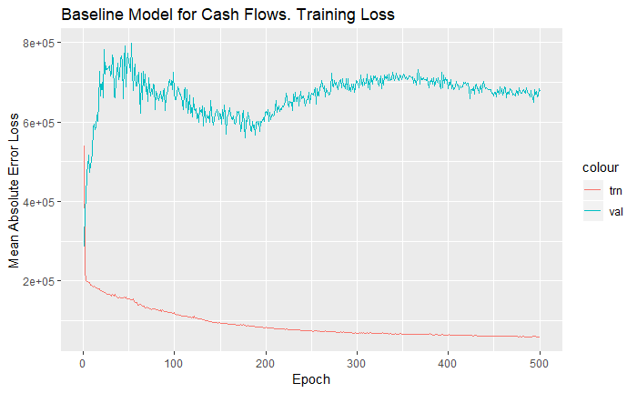

```r
history_py_cash14_trn <- py$toggplot_cash14_loss
history_py_cash14_val <- py$toggplot_cash14_loss_val

plot_learning(history_py_cash_trn = history_py_cash14_trn,
              history_py_cash_val = history_py_cash14_val,
              title = "Baseline Model for Cash Flows. Training Loss")
```

Thats not training! We’ll need to change our model or our data.

We’ll go through the motions of testing on the test set, as it allows us to build the functions we need for later attempts…

## Plot predictions vs Actuals for Test Set

```python
preds_train_14 = model_cash14.predict(x_train_accum)
preds_test_14  = model_cash14.predict(x_test_accum)
```

```r
plot_preds_train_vs_test <- function(preds_test,   preds_train,
                                     actuals_test, actuals_train,
                                     chart_examples = c(1),
                                     forecast_period){

  # predictions and y-arrays should be of dims = (n_examples, n_timesteps = days x 11, n_channels = 1)

  chart_dat_test  <- list()
  chart_dat_train <- list()

  for (i in 1:length(chart_examples)){

    #Chart data
    chart_dat_test[[length(chart_dat_test)+1]] <- cbind.data.frame(
                                                    x       = seq_along(preds_test[chart_examples[i],,1]),
                                                    preds   = preds_test[chart_examples[i],,1],
                                                    actuals = actuals_test[chart_examples[i],,1])

    chart_dat_train[[length(chart_dat_train)+1]]<- cbind.data.frame(
                                                    x       = seq_along(preds_train[chart_examples[i],,1]),
                                                    preds   = preds_train[chart_examples[i],,1],
                                                    actuals = actuals_train[chart_examples[i],,1])
  }

  #Min, max and avg over ALL examples
  Error_Min  = mean(apply(actuals_test, 1, FUN=min)  - apply(preds_test, 1, FUN=min))
  Error_Mean = mean(apply(actuals_test, 1, FUN=mean) - apply(preds_test, 1, FUN=mean))
  Error_Max  = mean(apply(actuals_test, 1, FUN=max)  - apply(preds_test, 1, FUN=max))

  # create chart function
  get_chart <- function(chart_dat, type_name, forecast_period){
    the_chart <- ggplot(data = chart_dat , aes(x=x/11))       +
                        geom_line(aes(y = preds,   col = "predict")) +
                        geom_line(aes(y = actuals, col = "actual"))     +
                        xlab("Forecast Day")                           +
                        ylab("O/D Balance")                  +
                        ggtitle(paste0(type_name,":",forecast_period,"Day Forecast"))
    return(the_chart)
  }

  # get charts
  chart_list <- list()

  for (i in 1:length(chart_examples)){

    chart_list[[length(chart_list)+1]] <- get_chart(chart_dat_train[[i]], "Train", forecast_period)

    chart_list[[length(chart_list)+1]] <- get_chart(chart_dat_test[[i]],  "Test",  forecast_period)
  }

return(list(chart_list, c(Error_Min, Error_Mean, Error_Max)))
}
```

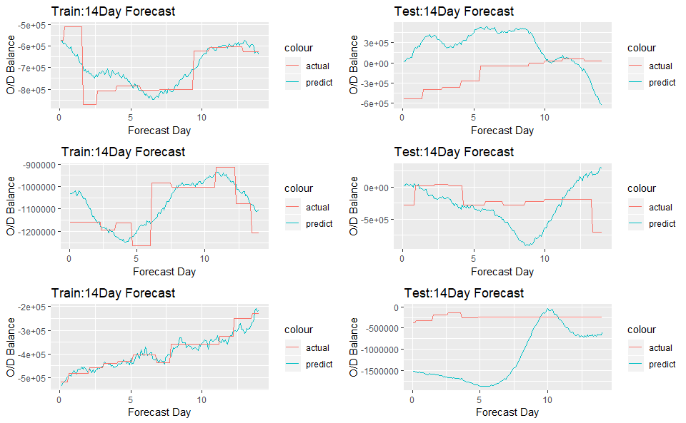

```r
set.seed(20180905)
random_examples14 <- round(runif(3, 1, dim(py$y_test_finaldate_14)[1]),0)

# Be sure to copy our data from python to R objects, so we can save it in a .RData file. Cannot save Python session.

preds_test14     <- py$preds_test_14
actuals_test14   <- py$y_test_finaldate_14

preds_train14    <- py$preds_train_14
actuals_train14  <- py$y_train_finaldate_14

Example_A14 <- plot_preds_train_vs_test(preds_test   = preds_test14,     preds_train    = preds_train14,
                                        actuals_test = actuals_test14,   actuals_train  = actuals_train14,
                                        chart_example= random_examples14,forecast_period= 14)

library(gridExtra)
grid.arrange(Example_A14[[1]][[1]], Example_A14[[1]][[2]], Example_A14[[1]][[3]],
             Example_A14[[1]][[4]], Example_A14[[1]][[5]], Example_A14[[1]][[6]],
             ncol=2, nrow=3)
```

```r
 #print min, avg, max errors
  print(paste0("Test set, mean error in 14day forecast of min  bank balance: ", round(Example_A14[[2]][1],0)))
```

```
[1] "Test set, mean error in 14day forecast of min  bank balance: 452059"
```

As we expected, the test results indicate the model is not usable.

# A Simpler Problem

Let’s ask the model to solve as simple a problem as we can, whats the lowest bank balance we should expect in the forthcoming two weeks? So we’ll train to a target of just one time step not fourteen*11. The time step will have just one output channel being:

– MinFortniteHence

It will take only 6 input channels (not 20, as previously):

– TransactionValue – AvgDaysToPay_Weighted – RollingBalance_Creditors – RollingBalance_Debtors – RollingBalance_Bank – MonthOfYr

We’ll also simply the model by having two less 1Dconv layers (11 as opposed to 13). This improves the ratio of weights to examples, fewer weights and more examples. Why more examples? With a max dilation of 2^11 we will reach 1024 timesteps, which is approx 3mths, not one year.

Hopefully, this will give us a better result in test

## Distribution of MinFortniteHence

First let’s extract the data and then plot its distribution, so we can see what an educated guess should look like. Our baseline is such a guess.

```python
train_gen_simple = yield_xy(x_train_py, y_train_py, records_per_example = 1024, batch_size =  64, step_size = 5)
x_train_simple, y_train_simple = get_accumulated_generator(train_gen_simple, "Train", verbose = False)

test_gen_simple  = yield_xy(x_test_py,  y_test_py,  records_per_example = 1024, batch_size = 100, step_size = 5)
x_test_simple,  y_test_simple  = get_accumulated_generator(test_gen_simple,  "Test ", verbose = False)

# Use only the followiong predictors:
# TransactionValue, AvgDaysToPay_Weighted, RollingBalance_Creditors,RollingBalance_Debtors,RollingBalance_Bank, MonthOfYr
x_train_6channels = x_train_simple[:, :, [1,2,5,6,7,8]]
x_test_6channels  = x_test_simple[:,  :, [1,2,5,6,7,8]]

# get single digit target for each example
y_train_finaldate_1 = y_train_simple[:,-1, 2].reshape((y_train_simple.shape[0], 1, 1))
y_test_finaldate_1  = y_test_simple[:, -1, 2].reshape((y_test_simple.shape[0],  1, 1))
```

The above python generates the data, we’ll plot distribution in the R package ggplot

```r
# save the data, these tensors take a long time to build.
x_train_6channels   <- py$x_train_6channels
x_test_6channels    <- py$x_test_6channels
y_train_finaldate_1 <- py$y_train_finaldate_1
y_test_finaldate_1  <- py$y_test_finaldate_1

# We can this data if it takes a long time to build:
# save(x_train_6channels, x_test_6channels, y_train_finaldate_1, y_test_finaldate_1,
#      file = "Cash_Flow_Deep_simpler.RData")
# To load the data again
# load("data.RData")

# chart data distributions
chart_dat_MinFortniteHence = data.frame(Seq = 1:dim(y_train_finaldate_1)[1]/365,
                                        MinFortniteHence = y_train_finaldate_1)

f <- ggplot(chart_dat_MinFortniteHence,aes(x = MinFortniteHence)) +
      geom_histogram(fill = "blue") +
      ggtitle("Histogram: Min Bank Balance 14Days Hence, Train")

g <- ggplot(chart_dat_MinFortniteHence, aes(x=Seq, y=MinFortniteHence)) +
      geom_line() + xlab("Year in Sequence") +
      ggtitle("MinFortniteHence Over Time, 2008 to 2017")

library(gridExtra)
grid.arrange(g, f, ncol=2, nrow=1)
```

[output not shown]

```r
model_cash1_shuf.compile(optimizer = Adam(),
                         loss      = 'mean_absolute_error')
epochs     = 500
batch_size =  64

history_cash1_shuf = model_cash1_shuf.fit(x               = x_train_6channels,
                                          y               = y_train_finaldate_1,
                                          batch_size      = batch_size,
                                          epochs          = epochs,
                                          validation_split= 0.2,
                                          shuffle         = True)
# save model
model_cash1_shuf.save('./SaveModels/model_cash1_shuf.h5')

# save history
import pickle
with open('./SaveModels/model_cash1_shuf_history.pickle', 'wb') as file_pi:
    pickle.dump(history_cash1_shuf.history, file_pi)
```

```python
from keras.models import load_model
import pickle

model_cash1_shuf   = load_model('./SaveModels/model_cash1_shuf.h5')
load_history       = open("./SaveModels/model_cash1_shuf_history.pickle","rb")
history_cash1_shuf = pickle.load(load_history)

toggplot_cash1_shuf_loss     = history_cash1_shuf['loss']
toggplot_cash1_shuf_loss_val = history_cash1_shuf['val_loss']
```

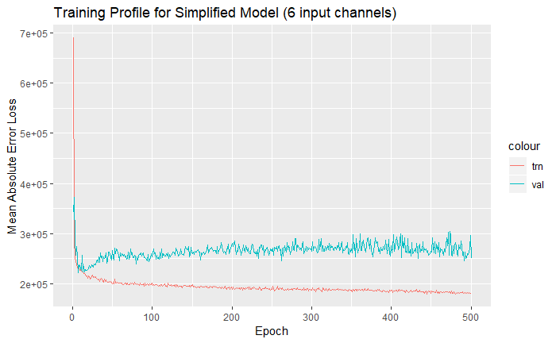

```r
history_py_cash1_shuf_trn <- py$toggplot_cash1_shuf_loss
history_py_cash1_shuf_val <- py$toggplot_cash1_shuf_loss_val

plot_learning(history_py_cash_trn = history_py_cash1_shuf_trn,
              history_py_cash_val = history_py_cash1_shuf_val,
              title = "Training Profile for Simplified Model (6 input channels)")
```

# A Slightly less Simple Approach !

From the above chart we can see that we succesfully trained a model. Let’s see if we can reduce mean error by increasing the duration to 6months per example and increase the predictors from 6 to all 20.

```python
train_gen_simple_6mth = yield_xy(x_train_py, y_train_py, records_per_example = 2048, batch_size =  64, step_size = 5)
x_train_simple_6mth, y_train_simple_6mth = get_accumulated_generator(train_gen_simple_6mth, "Train", verbose = False)

test_gen_simple_6mth  = yield_xy(x_test_py,  y_test_py,  records_per_example = 2048, batch_size = 100, step_size = 5)
x_test_simple_6mth,  y_test_simple_6mth  = get_accumulated_generator(test_gen_simple_6mth,  "Test ", verbose = False)

# get single digit target for each example
y_train_finaldate_1_6mth = y_train_simple_6mth[:,-1, 2].reshape((y_train_simple_6mth.shape[0], 1, 1))
y_test_finaldate_1_6mth  = y_test_simple_6mth[:, -1, 2].reshape((y_test_simple_6mth.shape[0],  1, 1))
```

```r
model_cash1_6mth = create_model_cash(days_forecast =  1, multby11      = False, predictor_qty = 20,
                                     n_filters     = 32, n_channels    = 1,     qty_dilations = 12,
                                     dropout_between_1Dconvs = True)

model_cash1_6mth.compile(optimizer = Adam(),
                         loss      = 'mean_absolute_error')
epochs     = 500
batch_size =  64

history_cash1_6mth = model_cash1_6mth.fit(x               = x_train_simple_6mth,
                                          y               = y_train_finaldate_1_6mth,
                                          batch_size      = batch_size,
                                          epochs          = epochs,
                                          validation_split= 0.2,
                                          shuffle         = True)
# save model
model_cash1_6mth.save('./SaveModels/model_cash1_6mth.h5')

# save history
import pickle
with open('./SaveModels/model_cash1_6mth_history.pickle', 'wb') as file_pi:
    pickle.dump(history_cash1_6mth.history, file_pi)
```

We’ll load the results from history and view the training progress.

```python
#because matplotlib is causing my environment to crash, we'll get data for charting in ggplot
toggplot_cash1_6mth_loss     = history_cash1_6mth['loss']
toggplot_cash1_6mth_loss_val = history_cash1_6mth['val_loss']
```

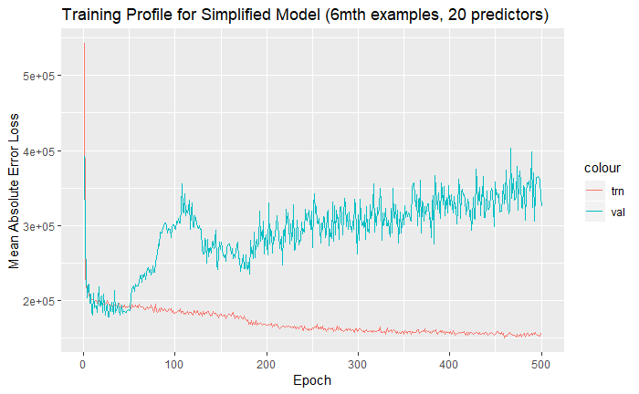

```r
history_py_cash1_6mth_trn <- py$toggplot_cash1_6mth_loss
history_py_cash1_6mth_val <- py$toggplot_cash1_6mth_loss_val

plot_learning(history_py_cash_trn = history_py_cash1_6mth_trn,
              history_py_cash_val = history_py_cash1_6mth_val,
              title = "Training Profile for Simplified Model (6mth examples, 20 predictors)")
```

Better than before, at approx 45 epochs. But still not very impressive as the error looks to be around £200k before validation diverges from training. Nevertheless let’s rebuild to 45 epochs and then see how it performs on test.

```r
model_cash1_6mth45epc = create_model_cash(days_forecast =  1, multby11      = False,
                                          predictor_qty = 20, qty_dilations = 12,
                                          n_filters     = 32, n_channels    = 1,
                                          dropout_between_1Dconvs = True)

model_cash1_6mth45epc.compile(optimizer = Adam(),
                              loss      = 'mean_absolute_error')
epochs     =  50
batch_size =  64

history_cash1_6mth45epc = model_cash1_6mth45epc.fit(x               = x_train_simple_6mth,
                                                    y               = y_train_finaldate_1_6mth,
                                                    batch_size      = batch_size,
                                                    epochs          = epochs,
                                                    validation_split= 0.2,
                                                    shuffle         = True)
# save model
model_cash1_6mth45epc.save('./SaveModels/model_cash1_6mth45epc.h5')

# save history
import pickle
with open('./SaveModels/model_cash1_6mth45epc_history.pickle', 'wb') as file_pi:
    pickle.dump(history_cash1_6mth45epc.history, file_pi)
```

```python
model_cash1_6mth45epc   = load_model('./SaveModels/model_cash1_6mth45epc.h5')
load_history            = open("./SaveModels/model_cash1_6mth45epc_history.pickle","rb")
history_cash1_6mth45epc = pickle.load(load_history)

preds_train_1_6mth45epc = model_cash1_6mth45epc.predict(x_train_simple_6mth)
preds_test_1_6mth45epc  = model_cash1_6mth45epc.predict(x_test_simple_6mth)
```

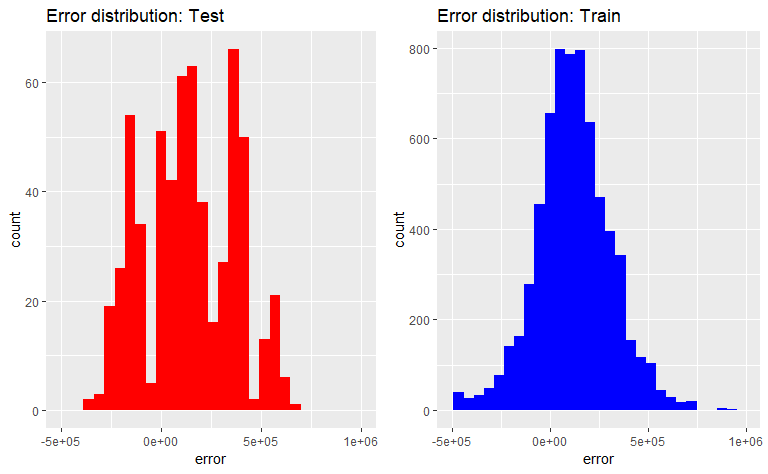

```r
preds_test1_6mth45epc    <- py$preds_test_1_6mth45epc
actuals_test1_6mth45epc  <- py$y_test_finaldate_1_6mth

preds_train1_6mth45epc   <- py$preds_train_1_6mth45epc
actuals_train1_6mth45epc <- py$y_train_finaldate_1_6mth

chart_dat_test <- cbind.data.frame(type  = "Test",
                                   error = as.vector(preds_test1_6mth45epc  - actuals_test1_6mth45epc))
chart_dat_train<- cbind.data.frame(type  = "Train",
                                   error = as.vector(preds_train1_6mth45epc - actuals_train1_6mth45epc))
chart_dat      <- rbind(chart_dat_test, chart_dat_train)

u <- ggplot(chart_dat,aes(x=error)) +
        geom_histogram(data=subset(chart_dat,type == 'Test'), fill = "red") +
        ggtitle("Error distribution: Test") +
        xlim(-500000, 1000000)

v <- ggplot(chart_dat,aes(x=error)) +
        geom_histogram(data=subset(chart_dat,type == 'Train'),fill = "blue") +
        ggtitle("Error distribution: Train") +
        xlim(-500000, 1000000)

library(gridExtra)
grid.arrange(u,v, ncol=2, nrow=1)
```

There is some resemblence between these distirbutions. We could do a formal test, but instead, let’s simply compare predicitions with actuals on the test set:

```r
the_rownames<- c("MinBalance14Days")

results_tab <- cbind.data.frame(Type          = the_rownames[1:dim(preds_train1_shuf)[3]],
                                MeanErr_Train = as.vector(colMeans(preds_train1_shuf - actuals_train1_shuf)),
                                StdDev_Train  = as.vector(sd(preds_train1_shuf - actuals_train1_shuf)),
                                MeanErr_Test  = as.vector(colMeans(preds_test1_shuf  - actuals_test1_shuf)),
                                StdDev_Test   = as.vector(sd(preds_test1_shuf  - actuals_test1_shuf)))
results_tab
```

| Type | MeanErr_Train | StdDev_Train | MeanErr_Test | StdDev_Test |
| --- | --- | --- | --- | --- |
| MinBalance14Days | 116863.4 | 252793.9 | 139634.1 | 228818.3 |

A mean error of £140k and SD of £230k is far better than our first model, but remains little better than an educated guess.

Adding dropout between the 1DConv layers causes the model to ‘forget’ some data which is an odd approach to time series, but it does appear to regularise the results.

Note, we can’t chart examples in the same way as our first example because there is only one figure, the minimum forecast for the coming 14 days, to chart.

## Conclusion on Wavenet Models for Cash Flow Forecasting

These models are training but are nowhere near providing useful forecasts. We must assume either :

1. the architecture is unsuitable for the problem
2. there are insufficient examples to train 1Dconv nets for this task
3. the data does not include the information needed to make useful forecasts

We don’t have much development time, but can attmept to elimiate possibility (a) by considering an LSTM model.

# LSTM Architecture

A more common approach to time series models is the LSTM. Introduction to LSTM’s in Keras at https://machinelearningmastery.com/keras-functional-api-deep-learning/

Keras LSTM models are straight forward to create, although it will be immediately apparent as to why the 1DConvs were einitially investigated. LSTM’s require more weights per time period than dilated 1DConv’s. The largest model we could attempt using an LSTM will have size=128, meaning it will look back 128 time steps. This is just 12 days.

```python
from keras.models import Model
from keras.layers import Input, Dense
from keras.layers.recurrent import LSTM
from keras.layers.wrappers import TimeDistributed
from keras.optimizers import Adam, TFOptimizer

def create_model_cash_LSTM(n_channels = 1, LSTM_size = 128, stacked = False):

  #parameters
  predictor_qty = 20

  # input layer
  # expected input data shape: (batch_size, timesteps, data_dim)
  input_sequence = Input(shape=(None, predictor_qty))
  x = input_sequence

  # feature extraction
  # params = inputs * outputs + outputs
  if (stacked):
    x = LSTM(LSTM_size, return_sequences=True)(x)

  # stacked layer for more complex feature identification
  x = LSTM(LSTM_size)(x)
  x = Dense(LSTM_size, activation='relu')(x)
  output = Dense(n_channels)(x)

  # output
  model = Model(inputs  = input_sequence,
                outputs = output)

  return(model)
```

[output not shown]

This new model need targets in 2D, not 3D.

```python
# get single digit target for each example
y_train_finaldate_1_LSTM = y_train_finaldate_1[:,:,0]
y_test_finaldate_1_LSTM  = y_test_finaldate_1[:,:,0]
```

```r
model_cash1_LSTM.compile(optimizer = Adam(),
                         loss      = 'mean_absolute_error')
epochs     = 1000
batch_size =   64

history_cash1_LSTM = model_cash1_LSTM.fit(x               = x_train_simple,
                                          y               = y_train_finaldate_1_LSTM,
                                          batch_size      = batch_size,
                                          epochs          = epochs,
                                          validation_split= 0.2,
                                          shuffle         = True)
# save model
model_cash1_LSTM.save('./SaveModels/model_cash1_LSTM.h5')

# save training history
with open('./SaveModels/model_cash1_LSTM_history.pickle', 'wb') as file_pi:
    pickle.dump(history_cash1_LSTM.history, file_pi)
```

```python
model_cash1_LSTM   = load_model('./SaveModels/model_cash1_LSTM.h5')
load_history       = open("./SaveModels/model_cash1_LSTM_history.pickle","rb")
history_cash1_LSTM = pickle.load(load_history)

toggplot_cash1_LSTM_loss     = history_cash1_LSTM['loss']
toggplot_cash1_LSTM_loss_val = history_cash1_LSTM['val_loss']
```

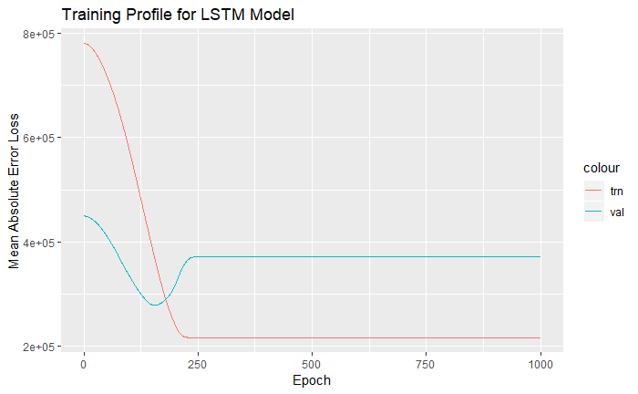

```r
history_py_cash1_LSTM_trn <- py$toggplot_cash1_LSTM_loss
history_py_cash1_LSTM_val <- py$toggplot_cash1_LSTM_loss_val

plot_learning(history_py_cash_trn = history_py_cash1_LSTM_trn,
              history_py_cash_val = history_py_cash1_LSTM_val,
              title = "Training Profile for LSTM Model")
```

```python
preds_train_1_LSTM = model_cash1_LSTM.predict(x_train_simple)
preds_test_1_LSTM  = model_cash1_LSTM.predict(x_test_simple)
```

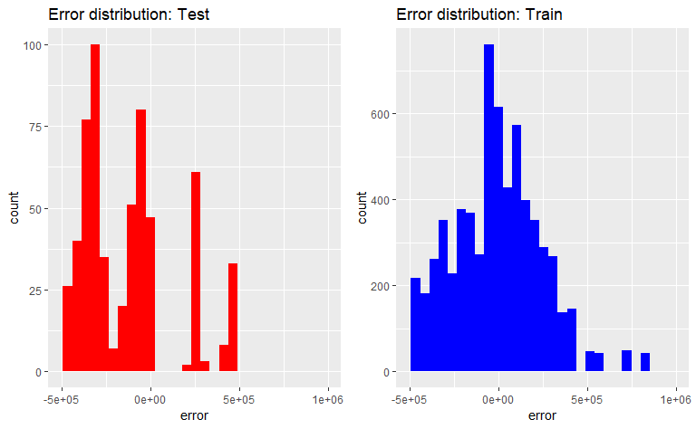

```r
preds_test1_LSTM    <- py$preds_test_1_LSTM
actuals_test1_LSTM  <- py$y_test_finaldate_1_LSTM

preds_train1_LSTM   <- py$preds_train_1_LSTM
actuals_train1_LSTM <- py$y_train_finaldate_1_LSTM

chart_dat_test <- cbind.data.frame(type  = "Test",
                                   error = as.vector(preds_test1_LSTM  - actuals_test1_LSTM))
chart_dat_train<- cbind.data.frame(type  = "Train",
                                   error = as.vector(preds_train1_LSTM - actuals_train1_LSTM))
chart_dat      <- rbind(chart_dat_test, chart_dat_train)

w <- ggplot(chart_dat,aes(x=error)) +
        geom_histogram(data=subset(chart_dat,type == 'Test'), fill = "red") +
        ggtitle("Error distribution: Test") +
        xlim(-500000, 1000000)

x <- ggplot(chart_dat,aes(x=error)) +
        geom_histogram(data=subset(chart_dat,type == 'Train'),fill = "blue") +
        ggtitle("Error distribution: Train") +
        xlim(-500000, 1000000)

library(gridExtra)
grid.arrange(w,x, ncol=2, nrow=1)
```

We could retrain the model to get the weights where the model scores the minimum error, which is at approx 140 epochs. However, even then, the mean absolute error is substantially higher than possible with the 1Dconv models. This first endeavour with LSTM’s has not improved upon our existing models.

# Overall Conclusion

Insufficient data for training!

We could further simplify the problem by changing it into a binary classification problem. For example we could ask the model “will we exceed some threshold in the coming 14 days?”. That may be of some use, but is currently judged not worth the effort.

With regret, this investigation closes without a model which can be deployed to production.

# APPENDIX. SQL for Data Extraction from Accounting System

The following T-SQL (for SQL Server 2016) was created to extract the cash transactions, debtors and creditors from the accounting system. The above notebook executes this T-SQL when is calls the SQL stored procedure in the second code chunk.

```r
DECLARE @MonthEndBeforeFirstDay DATETIME  = NULL;
DECLARE @OpeningBal_2150100 NUMERIC(12,2) = NULL;
DECLARE @OpeningBal_1850100 NUMERIC(12,2) = NULL;
DECLARE @OpeningBal_1950100 NUMERIC(12,2) = NULL;

--Prepare temp table
IF OBJECT_ID(N'tempdb..#tmp_StartingValues', N'U') IS NOT NULL
DROP TABLE [#tmp_StartingValues];

-- get starting values
SELECT
    ACCOUNT_NO, TRANS_DATE, BC_TRANS_VALUE
INTO
    [#tmp_StartingValues]
FROM
(
    SELECT ACCOUNT_NO, TRANS_DATE, BC_TRANS_VALUE, TRANS_DESC,
            ROW_NUMBER() OVER(PARTITION BY ACCOUNT_NO ORDER BY TRANS_DATE, ACCOUNT_NO) AS Seq
    FROM
        PUBLIC_NOMINAL_TRANSACTION_HISTORY
    WHERE
            TRANS_TYPE IN (N'bf') --bf means 'month ends', literally brought forward
            AND
            ACCOUNT_NO IN('2150100', -- purch ledger ctrl (creditors)
                              '1850100', -- sales ledger ctrl (debtors)
                              '1950100') -- bank current a/c
) As MonthEnds
WHERE
    Seq = 1 --we only want the starting value, the first in the sequence for each nominal account_no.

-- get those starting values...
SELECT @OpeningBal_2150100 = BC_TRANS_VALUE FROM [#tmp_StartingValues] WHERE ACCOUNT_NO = '2150100';
SELECT @OpeningBal_1850100 = BC_TRANS_VALUE FROM [#tmp_StartingValues] WHERE ACCOUNT_NO = '1850100';
SELECT @OpeningBal_1950100 = BC_TRANS_VALUE FROM [#tmp_StartingValues] WHERE ACCOUNT_NO = '1950100';
SELECT @MonthEndBeforeFirstDay = MIN(TRANS_DATE) FROM [#tmp_StartingValues];

--proceed with main task of building table of transactions, day by day

WITH
AllNominals
AS
(
    SELECT Src.ACCOUNT_NO, Src.TRANS_DATE, SYSTEM_DATE, Src.BC_TRANS_VALUE,
           Src.DOCUMENT_REF, Src.TRANS_TYPE, Src.TRANS_DESC
    FROM
        PUBLIC_NOMINAL_TRANSACTION_HISTORY AS Src
        LEFT OUTER JOIN
        [16_NominalTransactionHistoryMajorKey] AS Decode
        ON
        Src.ACCOUNT_NO       = Decode.ACCOUNT_NO
        AND Src.TRANS_DATE   = Decode.TRANS_DATE
        AND Src.DOCUMENT_REF = Decode.DOCUMENT_REF
    WHERE
            (NOT (Src.TRANS_TYPE IN (N'bf', N'by')))
            AND
            Src.ACCOUNT_NO IN('2150100', -- purch ledger ctrl (creditors)
                              '1850100', -- sales ledger ctrl (debtors)
                              '1950100') -- bank current a/c
            AND
            Decode.InternalOrExternal = 'External'

    UNION ALL

    SELECT Src.ACCOUNT_NO, Src.TRANS_DATE, SYSTEM_DATE, Src.BC_TRANS_VALUE, Src.DOCUMENT_REF,
           Src.TRANS_TYPE, Src.TRANS_DESCR
    FROM
        PUBLIC_NOMINAL_TRANSACTIONS AS Src
        LEFT OUTER JOIN
        [17_NominalTransactionCurrentMajorKey] As Decode
        ON
        Src.ACCOUNT_NO       = Decode.ACCOUNT_NO
        AND Src.TRANS_DATE   = Decode.TRANS_DATE
        AND Src.DOCUMENT_REF = Decode.DOCUMENT_REF
    WHERE
            (NOT (Src.TRANS_TYPE IN (N'bf', N'by')))
            AND
            Src.ACCOUNT_NO IN('2150100', -- purch ledger ctrl (creditors)
                              '1850100', -- sales ledger ctrl (debtors)
                              '1950100') -- bank current a/c
            AND
            Decode.InternalOrExternal = 'External'
)
,
Bank_1
AS
(
    --Get daily transaction total, null days where there is no data
    SELECT DISTINCT
        CASE WHEN ACCOUNT_NO = '1950100'
        -- bank transaction take place that day, disregard reconciliation (system) date
             THEN CalendarDay
             ELSE
                CASE WHEN SYSTEM_DATE > CalendarDay
                -- cannot know about the future for debtors/creditors
                     THEN SYSTEM_DATE
                     ELSE CalendarDay
                     END
             END
             AS CalendarDay,
        ACCOUNT_NO,
        SUM(COALESCE(BC_TRANS_VALUE,0)) AS DailyTotal
    FROM
        Decode_FinancialDays
        LEFT OUTER JOIN
        AllNominals
        ON Decode_FinancialDays.CalendarDay = AllNominals.TRANS_DATE

    WHERE
        CalendarDay > @MonthEndBeforeFirstDay
        --must be after the first month end for which we have starting balances
        AND
        CalendarDay < DATEADD(dd,-30, GETDATE())
        --30 days in past, final month has no useful forecasts
    GROUP BY
        CASE WHEN ACCOUNT_NO = '1950100'
        -- bank transaction take place that day, disregard reconciliation (system) date
             THEN CalendarDay
             ELSE
                CASE WHEN SYSTEM_DATE > CalendarDay
                -- cannot know about the future for debtors/creditors
                     THEN SYSTEM_DATE
                     ELSE CalendarDay
                     END
             END,
        ACCOUNT_NO

)
,
Bank_2
AS
(
    SELECT DISTINCT
        CalendarDay,
        EOMONTH(CalendarDay) AS MonthEnd,
        SUM(CASE WHEN ACCOUNT_NO = '1950100' THEN DailyTotal ELSE 0 END)
            OVER (ORDER BY CalendarDay) + @OpeningBal_1950100
            AS RollingBalance_Bank,

        SUM(CASE WHEN ACCOUNT_NO = '2150100' THEN DailyTotal ELSE 0 END)
            OVER (ORDER BY CalendarDay) + @OpeningBal_2150100
            AS RollingBalance_Creditors,

        SUM(CASE WHEN ACCOUNT_NO = '1850100' THEN DailyTotal ELSE 0 END)
            OVER (ORDER BY CalendarDay) + @OpeningBal_1850100
            AS RollingBalance_Debtors
    FROM
        Bank_1
)
,
Bank_3
AS
(
    SELECT
        CalendarDay,
        RollingBalance_Creditors,
        RollingBalance_Debtors,
        RollingBalance_Bank,
        MAX(RollingBalance_Bank) OVER (ORDER BY CalendarDay ROWS BETWEEN CURRENT ROW AND 14 FOLLOWING)
          AS MaxFortniteHence,
        MIN(RollingBalance_Bank) OVER (ORDER BY CalendarDay ROWS BETWEEN CURRENT ROW AND 14 FOLLOWING)
          AS MinFortniteHence,
        AVG(RollingBalance_Bank) OVER (ORDER BY CalendarDay ROWS BETWEEN CURRENT ROW AND 14 FOLLOWING)
          AS AvgFortniteHence,
        MAX(RollingBalance_Bank) OVER (ORDER BY CalendarDay ROWS BETWEEN CURRENT ROW AND 30 FOLLOWING)
          AS MaxMonthHence,
        MIN(RollingBalance_Bank) OVER (ORDER BY CalendarDay ROWS BETWEEN CURRENT ROW AND 30 FOLLOWING)
          AS MinMonthHence,
        AVG(RollingBalance_Bank) OVER (ORDER BY CalendarDay ROWS BETWEEN CURRENT ROW AND 30 FOLLOWING)
          AS AvgMonthHence,
        LEAD(RollingBalance_Bank, 14, 0) OVER(ORDER BY CalendarDay) AS RollingBalance_Bank14Hence,
        LEAD(RollingBalance_Bank, 30, 0) OVER(ORDER BY CalendarDay) AS RollingBalance_Bank30Hence
    FROM
        Bank_2
)
,
SaleAndPurchaseTransactions
AS
(
    SELECT
        CASE AllNominals.ACCOUNT_NO
            WHEN '2150100' THEN 'Purchase'
            WHEN '1850100' THEN 'Sale'
            ELSE 'Unknown'
            END AS TransType,
        AllNominals.TRANS_DATE  AS TransactionDate,
        AllNominals.SYSTEM_DATE AS SystemDate,
        Decode_NominalTransactionTypes.[description]   AS TransactionType,
        AllNominals.BC_TRANS_VALUE As TransactionValue,
        AllNominals.DOCUMENT_REF AS TransactionDocRef
```

```r
    FROM
        AllNominals

        INNER JOIN
        PUBLIC_NOMINAL_MASTER
        ON AllNominals.ACCOUNT_NO = PUBLIC_NOMINAL_MASTER.ACCOUNT_NO

        LEFT OUTER JOIN
        Decode_NominalTransactionTypes
        ON AllNominals.TRANS_TYPE = Decode_NominalTransactionTypes.code
    WHERE
        AllNominals.ACCOUNT_NO IN('2150100','1850100')
)
,
TransactionsWithAccount
AS
(
    SELECT
        TransType,
        TransactionDate,
        SystemDate,
        TransactionType,
        TransactionValue,
        TransactionDocRef,
        INVOICE_TYPE,
        LTRIM(COALESCE(CAST(AllSuppTrans.ACCOUNT_NO AS VARCHAR),
                       CAST(AllCustTrans.ACCOUNT_NO AS VARCHAR))) AS Account
    FROM
        SaleAndPurchaseTransactions
        LEFT OUTER JOIN
        (
            SELECT TRANS_DATE, DOCUMENT_REF, TRANS_TYPE, TRANS_VALUE#1, ACCOUNT_NO
            FROM PUBLIC_SUPPLIER_TRANSACTIONS
            UNION
            SELECT TRANS_DATE, DOCUMENT_REF, TRANS_TYPE, TRANS_VALUE#1, ACCOUNT_NO
            FROM PUBLIC_SUPPLIER_TRANSACTION_HISTORY
        ) AS AllSuppTrans
        ON  SaleAndPurchaseTransactions.TransactionDate   = AllSuppTrans.TRANS_DATE
        AND SaleAndPurchaseTransactions.TransactionDocRef = AllSuppTrans.DOCUMENT_REF
        AND SaleAndPurchaseTransactions.TransactionValue  = AllSuppTrans.TRANS_VALUE#1

        LEFT OUTER JOIN
        (
            SELECT TRANS_DATE, TRANS_REF, TRANS_TYPE, TRANS_VALUE#1, ACCOUNT_NO, INVOICE_TYPE
            FROM PUBLIC_CUSTOMER_TRANSACTIONS
            UNION
            SELECT TRANS_DATE, TRANS_REF, TRANS_TYPE,       VALUE#1, ACCOUNT_NO, INVOICE_TYPE
            FROM PUBLIC_CUSTOMER_TRANSACTION_HISTORY
        ) AS AllCustTrans
        ON  SaleAndPurchaseTransactions.TransactionDate   = AllCustTrans.TRANS_DATE
        AND SaleAndPurchaseTransactions.TransactionDocRef = AllCustTrans.TRANS_REF
        AND SaleAndPurchaseTransactions.TransactionValue  = AllCustTrans.TRANS_VALUE#1
)
,
OtherTransactions --wages, bank charges, finance movements, vat in/out etc.
AS
(
    SELECT DISTINCT
            'NonSaleOrPurchase'        AS TransType,
            CalendarDay                AS TransactionDate,
            CalendarDay                AS SystemDate,
            --otherwise the postingdealy_days is skewed by bank reconciliation dates
            'Manual Journal'           AS TransactionType,
            COALESCE(BC_TRANS_VALUE,0) AS TransactionValue,
            BankNoms.DOCUMENT_REF      AS TransactionDocRef,
            'NA'                       AS INVOICE_TYPE,
            '0000'                     AS Account
        FROM
            Decode_FinancialDays
            LEFT OUTER JOIN
            (SELECT * FROM AllNominals WHERE ACCOUNT_NO = '1950100') AS BankNoms
            ON Decode_FinancialDays.CalendarDay = BankNoms.TRANS_DATE
        WHERE
            CalendarDay > CONVERT(DATETIME, '2009-09-30', 102)
            AND
            CalendarDay < DATEADD(dd,-30, GETDATE()) --30 days in past, final month has no useful forecasts
            AND
            LEFT(BankNoms.DOCUMENT_REF,1) = 'N'
)
,
FirstTemplate_ExcMeans
AS
(
SELECT
    TransType,
    TransactionDate,
    SystemDate,
    TransactionType,
    TransactionValue,
    TransactionDocRef,

    CASE TransType
         WHEN 'Purchase'
            THEN 'Not a Sale'
         WHEN 'NonSaleOrPurchase'
            THEN 'Not a Sale'
         ELSE COALESCE([Decode_Invoice_Type_Groups].[Group], 'Unspecified')
         END
         AS SalesCategory,

    CASE
        WHEN TransType = 'Sale'
            THEN 'Not a Purchase'
        WHEN TransType = 'NonSaleOrPurchase'
            THEN 'Not a Purchase'
        WHEN Account IN ('8609', '1196')
            THEN 'Finance'
        WHEN Account IN ('2610','2481','1765','1758','1649','1353','1336','1328','1322','1292','1233',
                         '1225','1133','1114','1113','1107')
            THEN 'Machinery'
        WHEN Account IN ('8702','8526','2625','2474','2064','2054','1993','1962','1956','1867','1781',
                         '1773','1760','1742','1727','1494','1391','1290','1262','1261','1259','1258',
                         '1250','1206','1191','1183','1176','1151','1150','1131','1101','1100')
            THEN 'Parts'
        ELSE 'Unspecified'
        END
        AS PurchaseCategory,

    Account,

    CASE TransType
        WHEN 'Sale'     THEN PUBLIC_CUSTOMER_MASTER.AVE_DAYS_TO_PAY
        WHEN 'Purchase' THEN PUBLIC_SUPPLIER_MASTER.AVE_DAYS_TO_PAY
        WHEN 'NonSaleOrPurchase' THEN 3
        ELSE 'Unknown'
        END
        AS AvgDaysToPay,

    CASE TransType
        WHEN 'Sale'     THEN PUBLIC_CUSTOMER_MASTER.AVE_AMOUNT_PAID
        WHEN 'Purchase' THEN PUBLIC_SUPPLIER_MASTER.AVE_PAID_AMOUNT
        WHEN 'NonSaleOrPurchase' THEN 5000
        ELSE 'Unknown'
        END
        AS AvgValuePaid,

    CASE TransType
        WHEN 'Sale'     THEN PUBLIC_CUSTOMER_MASTER.NO_OF_PAYMENTS
        WHEN 'Purchase' THEN PUBLIC_SUPPLIER_MASTER.NO_OF_PAYMENTS
        WHEN 'NonSaleOrPurchase' THEN 300
        ELSE 'Unknown'
        END
        AS QtyOfPayments
FROM
    (
        SELECT * FROM TransactionsWithAccount
        UNION ALL
        SELECT * FROM OtherTransactions
    )
    AS AllTransactions

    LEFT OUTER JOIN
    PUBLIC_CUSTOMER_MASTER
    ON AllTransactions.Account = LTRIM(PUBLIC_CUSTOMER_MASTER.ACCOUNT_NO)

    LEFT OUTER JOIN
    PUBLIC_SUPPLIER_MASTER
    ON AllTransactions.Account = LTRIM(PUBLIC_SUPPLIER_MASTER.ACCOUNT_NO)

    LEFT OUTER JOIN
    [Decode_Invoice_Type_Groups]
    ON AllTransactions.INVOICE_TYPE = [Decode_Invoice_Type_Groups].INVOICE_TYPE

)
,
Mean_ValuePaidAndQtyOfPayments_ForMissingData
AS
(
    SELECT
        TransType,
        ROUND(AVG(TransactionValue),-1) AS AvgValuePaid_ForMissingData,
        ROUND(COUNT(TransactionValue)
              /
              COUNT(DISTINCT Account)
              ,-1)
              AS QtyOfPayments_ForMissingData
    FROM
        FirstTemplate_ExcMeans
    WHERE
        --missing data is defined as:
        AvgDaysToPay = 0
        OR
        AvgDaysToPay > 65000 -- seems to be an Ibcos default which must be rubbish
        OR
        AvgDaysToPay IS NULL
    GROUP BY
        TransType
)
,
Mean_DaysToPay_ForMissingData
AS
--Cannot calculate indepenently, must simply use average of those transactions where we have data
--(NOT missing)
(
    SELECT
        TransType,
        ROUND(SUM(AvgDaysToPay * ABS(TransactionValue))
              /
              SUM(ABS(TransactionValue))
              ,0)
              AS AvgDaysToPay_ForMissingData
    FROM
        FirstTemplate_ExcMeans
    WHERE
        --NOT missing data is defined as:
        AvgDaysToPay != 0
        AND
        AvgDaysToPay < 65000 -- seems to be an Ibcos default which must be rubbish
        AND
        AvgDaysToPay IS NOT NULL
    GROUP BY
        TransType
)
,
SecondTemplate
AS
(
    SELECT
        FirstTemplate_ExcMeans.TransType AS SaleOrPurchase,
        TransactionDate,
        DATEDIFF(dd, TransactionDate, SystemDate) AS PostingDelayDays,
        TransactionType,
        TransactionValue,
        TransactionDocRef,
        SalesCategory,
        PurchaseCategory,
        Account,
```

```r
        CASE WHEN TransactionType = 'Sales Cash Received'
                  OR
                  TransactionType = 'Purchase Cash Payment'
             THEN 3  --cash payments clear quick!
             ELSE
                -- handle missing data
                CASE WHEN AvgDaysToPay = 0 OR AvgDaysToPay > 65000 OR AvgDaysToPay IS NULL
                     THEN Mean_DaysToPay_ForMissingData.AvgDaysToPay_ForMissingData
                     ELSE AvgDaysToPay
                     END
             END
             AS AvgDaysToPay,

        COALESCE(AvgValuePaid,
                 Mean_ValuePaidAndQtyOfPayments_ForMissingData.AvgValuePaid_ForMissingData)
                 AS AvgValuePaid,

        COALESCE(QtyOfPayments,
                 Mean_ValuePaidAndQtyOfPayments_ForMissingData.QtyOfPayments_ForMissingData)
                 AS QtyOfPayments

    FROM
        FirstTemplate_ExcMeans

        LEFT OUTER JOIN
        Mean_DaysToPay_ForMissingData
        ON FirstTemplate_ExcMeans.TransType = Mean_DaysToPay_ForMissingData.TransType

        LEFT OUTER JOIN
        Mean_ValuePaidAndQtyOfPayments_ForMissingData
        ON FirstTemplate_ExcMeans.TransType = Mean_ValuePaidAndQtyOfPayments_ForMissingData.TransType

)
,
DistinctTransactionTypes
AS
(
    SELECT DISTINCT
        SaleOrPurchase,
        SalesCategory,
        PurchaseCategory
    FROM
        SecondTemplate
    WHERE
        NOT(SaleOrPurchase = 'Purchase' AND SalesCategory    = 'Not a Sale')
        OR
        NOT(SaleOrPurchase = 'Sale'     AND PurchaseCategory = 'Not a Purchase')
)
,
DistinctTransactionTypesAndDays
AS
(
    SELECT
        CalendarDay,
        SaleOrPurchase,
        SalesCategory,
        PurchaseCategory
    FROM
        DistinctTransactionTypes
        CROSS JOIN
        Decode_FinancialDays
    WHERE
        CalendarDay > CONVERT(DATETIME, '2009-09-30', 102)
        AND
        CalendarDay < GETDATE()
)

SELECT
    DistinctTransactionTypesAndDays.CalendarDay,

    CASE WHEN SUM(TransactionValue) = 0
         THEN 0
         ELSE SUM(COALESCE(PostingDelayDays,0) * ABS(TransactionValue))
              /
              SUM(ABS(TransactionValue))
         END
         AS PostingDelayDays_Weighted,

    DistinctTransactionTypesAndDays.SaleOrPurchase,

    CASE WHEN DistinctTransactionTypesAndDays.SaleOrPurchase = 'Sale'
         THEN DistinctTransactionTypesAndDays.SalesCategory
         ELSE DistinctTransactionTypesAndDays.PurchaseCategory
         END
         AS Category,
    TransactionType,
    COALESCE(SUM(TransactionValue),0) AS TransactionValue,

    CASE WHEN SUM(TransactionValue) = 0
         THEN AVG(AvgDaysToPay)
         --else weighted average
         ELSE SUM(AvgDaysToPay * ABS(TransactionValue))
                /
              SUM(ABS(TransactionValue))
         END
         AS AvgDaysToPay_Weighted,

    CASE WHEN SUM(TransactionValue) = 0
         THEN AVG(AvgValuePaid)
         --else weighted average
         ELSE SUM(AvgValuePaid * TransactionValue)
                /
              SUM(TransactionValue)
         END
         AS AvgValuePaid_Weighted,

    CASE WHEN SUM(TransactionValue) = 0
         THEN AVG(QtyOfPayments)
         -- else weigthed average
         ELSE SUM(QtyOfPayments* ABS(TransactionValue))
                /
              SUM(ABS(TransactionValue))
         END
         AS QtyOfPayments_Weighted,

    RollingBalance_Creditors,
    RollingBalance_Debtors,
    RollingBalance_Bank,

    RollingBalance_Bank14Hence,
    MinFortniteHence,
    AvgFortniteHence,
    MaxFortniteHence,

    RollingBalance_Bank30Hence,
    MinMonthHence,
    AvgMonthHence,
    MaxMonthHence

FROM
    DistinctTransactionTypesAndDays
    --Teamplate for transaction types ensures we have same trans types for all days,
    --even if zero transaction value
    LEFT OUTER JOIN
    SecondTemplate
    ON  DistinctTransactionTypesAndDays.SaleOrPurchase   = SecondTemplate.SaleOrPurchase
    AND DistinctTransactionTypesAndDays.SalesCategory    = SecondTemplate.SalesCategory
    AND DistinctTransactionTypesAndDays.PurchaseCategory = SecondTemplate.PurchaseCategory
    AND DistinctTransactionTypesAndDays.CalendarDay      = SecondTemplate.TransactionDate

    INNER JOIN
    Bank_3
    ON DistinctTransactionTypesAndDays.CalendarDay = Bank_3.CalendarDay

WHERE
    DistinctTransactionTypesAndDays.CalendarDay < DATEADD(dd,-30, GETDATE())

GROUP BY
    DistinctTransactionTypesAndDays.CalendarDay,
    DistinctTransactionTypesAndDays.SaleOrPurchase,

    CASE WHEN DistinctTransactionTypesAndDays.SaleOrPurchase = 'Sale'
         THEN DistinctTransactionTypesAndDays.SalesCategory
         ELSE DistinctTransactionTypesAndDays.PurchaseCategory
         END,

    TransactionType,
    RollingBalance_Creditors,
    RollingBalance_Debtors,
    RollingBalance_Bank,

    MinFortniteHence,
    AvgFortniteHence,
    MaxFortniteHence,

    MinMonthHence,
    AvgMonthHence,
    MaxMonthHence,

    RollingBalance_Bank14Hence,
    RollingBalance_Bank30Hence
ORDER BY
    CalendarDay,
    SaleOrPurchase,
    Category
```